[figure not shown]

## Antares R packages

[See activity dashboard](https://rte-antares-rpackage.github.io/rPackagesRte/dashboard.html)

[interactive chart not shown]

## EN

Find here the most popular R packages developed by Rte around Antares. You can edit a study, read simulation results and visualize them!

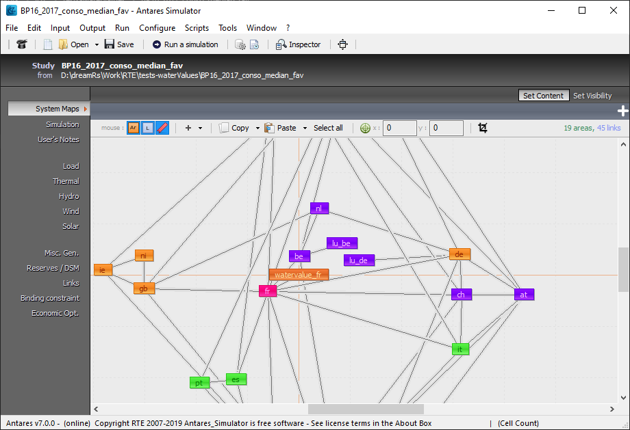

#### **[antaresRead](https://rte-antares-rpackage.github.io/antaresRead/index.html)**

Import, manipulate and explore results generated by 'Antares', a powerful open source software developed by RTE (Réseau de Transport d’Électricité) to simulate and study electric power systems.

#### **[antaresEditObject](https://rte-antares-rpackage.github.io/antaresEditObject/index.html)**

Edit an Antares study before running a simulation. Methods are provided to create (and remove) areas, links between them, thermal cluster and binding constraints.

[figure not shown]

#### **antaresProcessing**

Process results generated by Antares. Allows to create new columns like net load, load factors, upward and downward margins or to compute aggregated statistics like economic surpluses of consumers, producers and sectors.

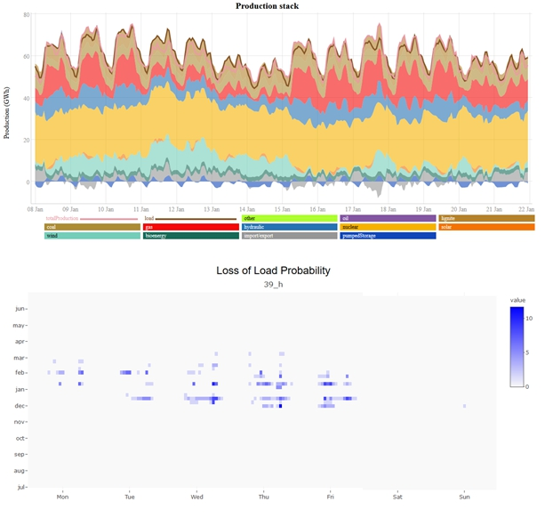

#### **[antaresViz](https://rte-antares-rpackage.github.io/antaresViz/index.html)**

Visualize results generated by Antares. This package provides functions that create interactive charts to help users visually explore the results of their simulations.

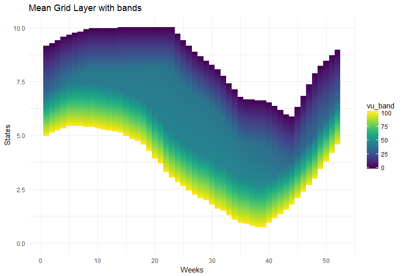

#### **[antaresWaterValues](https://rte-antares-rpackage.github.io/antaresWaterValues/index.html)**

Compute water values to use in Antares. This package allows to run specific simulations in Antares from within R, and to use the results of these simulations to compute Bellman values and water values for each stock level and each week of the year.

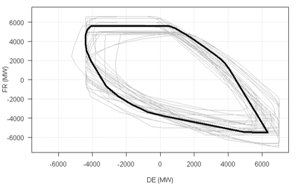

#### **fbClust**

This package allows to analyse a database of Flow-Based domains and to cluster and extract the most representative domains to be applied to an Antares study, as well as probability matrices to allocate the domains on prospective studies.

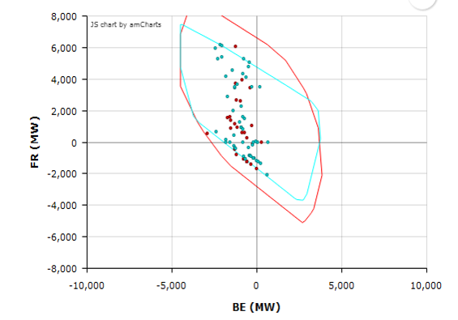

#### **fbAntares**

This package allows to add Flow-Based domains as binding constraints in Antares. It also provides a method to reduce the complexity of Flow-Based domains, and visualization functions.

## FR

Retouvez ici les packages R les plus populaires développés par Rte autour d’Antares. Vous pouvez éditer une étude, lire les résultats de simulations et les visualiser !

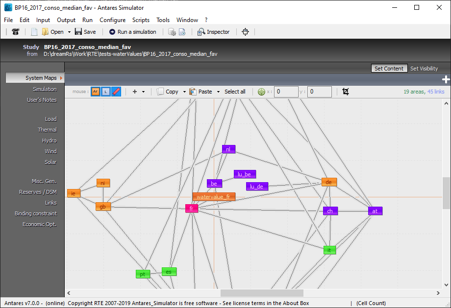

#### **[antaresRead](https://rte-antares-rpackage.github.io/antaresRead/index.html)**

Importer, manipuler et explorer les résultats d'une simulation Antares.

#### **[antaresEditObject](https://rte-antares-rpackage.github.io/antaresEditObject/index.html)**

Modifier une étude Antares avant de lancer une simulation. Les méthodes fournies permettent notamment de créer et de supprimer les zones, les liens entre elles, les clusters thermiques et les contraintes couplantes.

[figure not shown]

#### **antaresProcessing**

Traiter les résultats Antares. Ce package permet notamment de créer des nouvelles colonnes telle que la charge nette, les facteurs de charge, les marges ascendantes et descendantes. Il facilite également le calcul de statistiques agrégées.

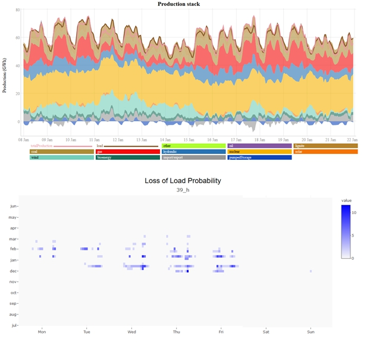

#### **[antaresViz](https://rte-antares-rpackage.github.io/antaresViz/index.html)**

Visualiser les résultats générés par Antares. Les fonctions fournies permettent de créer des graphiques interactifs qui permettent d'explorer les résultats des simulations.

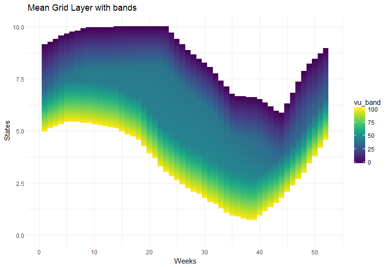

#### **[antaresWaterValues](https://rte-antares-rpackage.github.io/antaresWaterValues/index.html)**

Calculer les valeurs de l'eau à utiliser dans Antares. Ce package permet de lancer des simulations spécifiques dans Antares depuis R, et, à partir des résultats, de calculer les valeurs de Bellman et valeurs de l'eau pour chaque niveau de stock et chaque semaine.

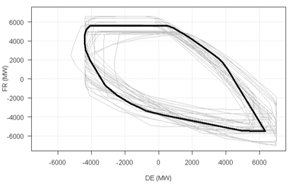

#### **fbClust**

Ce package permet d'analyser une base de données de domaines Flow-Based, de les clusteriser et d'extraire les domaines les plus représentatifs pour les utiliser dans des études Antares, ainsi que des matrices de proabailité pour allouer ces domaines à des études prospectives.

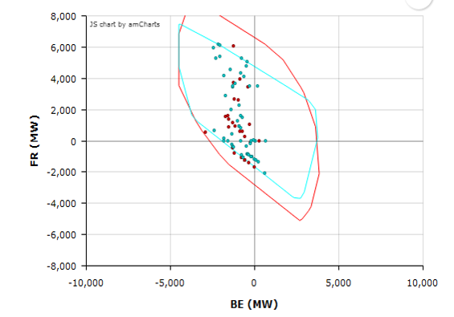

#### **fbAntares**

Ce package permet d'ajouter des domaines Flow-Based dans Antares en tant que contraintes couplantes. Il fournit aussi une méthode pour réduire la complexité des domaines, et des fonctions de visualisation.